# Start codon context for Neurospora crassa

Edward Wallace, ewjwallace@gmail.com

16 Jan 2019

# Summary

This presents the analysis of Neurospora start codon usage and context. This uses the N. crassa translation estimates from Ivanov 2017, strain FGSC 2489. RNA data and TE estimates are from Yu 2015, same strain.

For “enough RNA” we pick the top ~40% (4000) by RNA abundance, because the N. crassa genome is much larger (9722 genes) than the other fungi we are addressing.

# Here we go

## Expression: RNA abundance and ribosome-protected-fragments

### Load expression data

```
## # A tibble: 9,722 x 8
##    Gene       WT1A   WT1B   WT2A   WT2B   HS1A   HS1B    RPF
##    <chr>     <dbl>  <dbl>  <dbl>  <dbl>  <dbl>  <dbl>  <dbl>
##  1 NCU06110 44987. 48332. 30355. 29159  28086. 30914. 35305.
##  2 NCU09345 39472. 41967. 30206. 31589. 32871. 32557. 34777.
##  3 NCU01528 19089. 18529. 22677  23985. 19573. 19484. 20556.
##  4 NCU02003 16107. 16344. 19838. 19027. 20928. 22821. 19178.
##  5 NCU16635 15646. 14783. 11187. 14863. 16376. 10478. 13889.
##  6 NCU10042 12865. 12418. 11894. 12734  12980. 10153. 12174.
##  7 NCU05495  7567.  7515. 10594. 11068   5313.  4177.  7706.
##  8 NCU02193  5046.  5109.  8775. 10355.  4738.  9384.  7234.
##  9 NCU04276  4626.  4366.  7922.  7225.  7064.  8340.  6590.
## 10 NCU08332  6563.  6427.  6318.  6337.  5620.  6361.  6271.
## # ... with 9,712 more rows
```

Reasonably, NCU01528 is GAPDH. NCU10042 is enolase-1. NCU02003 is elongation factor 1-alpha. NCU02193 is Pdc1. NCU01754 is Adh1.

Weirdly high expression of thiazole/thiamine biosynthetic enzymes NCU06110/thi4, NCU09345/nmt1.

NCU05495/ccg-16 is CVNH domain-containing protein. NCU08332/hex-1 is isworonin body major protein.

Several hypothetical proteins (NCU16635/NCU04276). Wow. check footprint locations.

#### Check RPFs vs RNA in Yu 2015

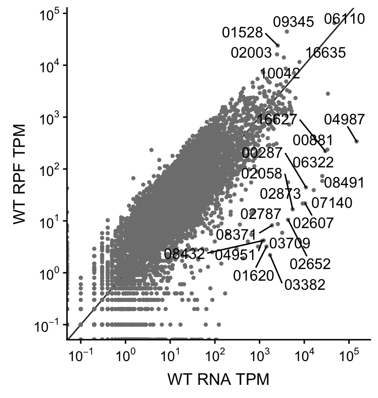

The numbers for NCU04987 are so absurd that it is surely a misannotation of a ncRNA. NCU16627 also looks very strange.

#### Check replicability

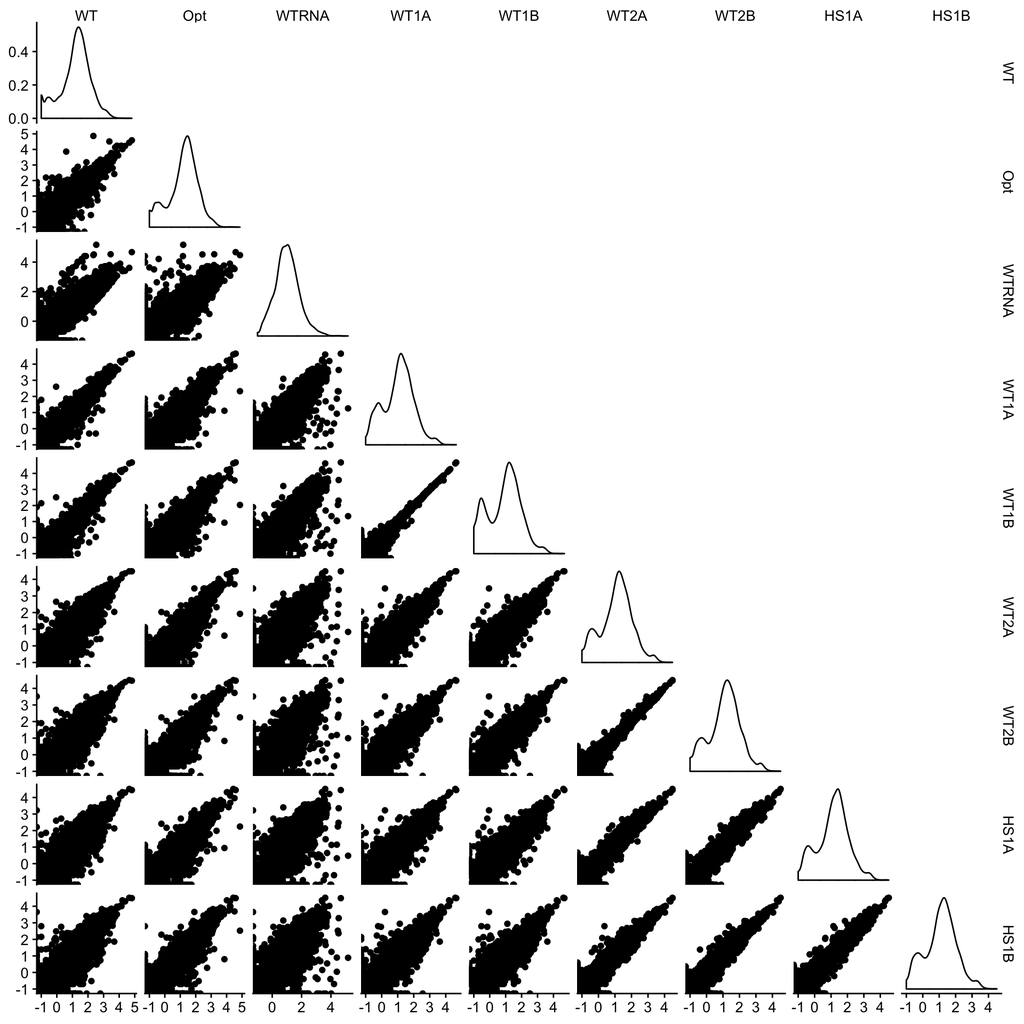

### Ribosome occupancy mostly tracks RNA abundance

## ATG Context

### Load context data

```
## # A tibble: 9,722 x 19
##    Gene  aATG.context aATG.pos d1.context d1.posTSS d1.posATG d1.frame
##    <chr> <chr>           <dbl> <chr>          <dbl>     <dbl>    <dbl>
##  1 NCU0… ACCATCATCGC…      798 AGCCTTTCC…       819        21        0
##  2 NCU0… GCTTTTGGTGT…      206 CCTTTACGC…       324       118        1
##  3 NCU0… ATCGCACTTTC…      365 AAGACGACC…       522       157        1
##  4 NCU0… TCGATAGAAGA…     1382 AGTCCGACC…      1485       103        1
##  5 NCU0… GACCGATTTAG…      713 GGGCCGCCA…       780        67        1
##  6 NCU0… CCACCGCCCAC…      558 AGGATTCCA…       748       190        1
##  7 NCU0… CAAATACTCAC…        1 GAGTGGAAG…       163       162        0
##  8 NCU0… TTTCTGCCCAA…     1457 GGCGTGAGC…      1680       223        1
##  9 NCU0… GTGGACACCGG…        1 ATCGAAGCG…        96        95        2
## 10 NCU0… ATGGTGGTCAA…        1 AAAGTGCTC…       118       117        0
## # ... with 9,712 more rows, and 12 more variables: d2.context <chr>,
## #   d2.posTSS <dbl>, d2.posATG <dbl>, d2.frame <dbl>, u1.context <chr>,
## #   u1.posTSS <dbl>, u1.posATG <dbl>, u1.frame <dbl>, u2.context <chr>,
## #   u2.posTSS <dbl>, u2.posATG <dbl>, u2.frame <dbl>
```

### Annotated ATGs have a Kozak consensus sequence

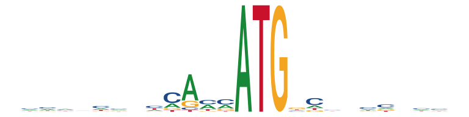

### Highly translated Annotated ATGs have a Kozak consensus sequence

That’s for hiTrans, the top 4% (400) translated genes by RPF TPM.

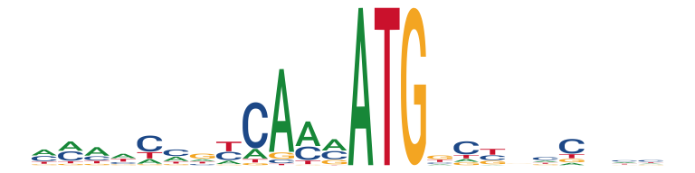

[figure not shown]

### Cytoplasmic Ribosome Annotated ATGs have a Kozak consensus sequence

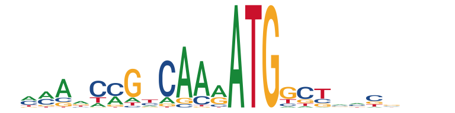

[figure not shown]

### Almost all cytoribo genes are highly translated

Venn diagram

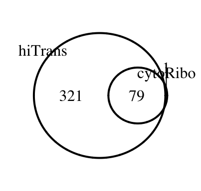

### Downstream ATGs don’t have a consensus

First downstream ATG

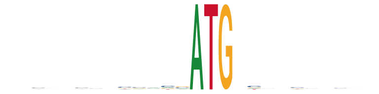

### Downstream ATGs in frame and highly translated don’t have a consensus

Except for 3rd-codon-position bias.

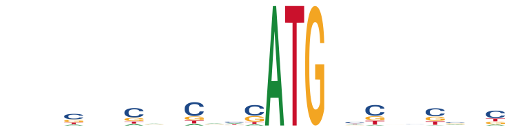

## Calculate Information content and scores of consensus motif

### Calculate a wide and a narrow consensus sequence

Calculate motif score against the position weight matrix (pwm) for both **narrow** (-4 from ATG through to ATG) and **wide** (-10 from ATG) kozak consensus motif. These motifs are taken from the top 5% highly translated genes.

### Estimate the information content

Using the sequence logo, details on https://en.wikipedia.org/wiki/Sequence_logo

```
## # A tibble: 6 x 4
##   Genes    ATG   Width  Infon
##   <chr>    <chr> <chr>  <dbl>
## 1 All      aATG  narrow 1.54
## 2 HiTrans  aATG  narrow 2.91
## 3 CytoRibo aATG  narrow 3.32
## 4 All      d1ATG narrow 0.276
## 5 HiTrans  d1ATG narrow 0.423
## 6 CytoRibo d1ATG narrow 0.610
```

### Estimate information content per base across start context

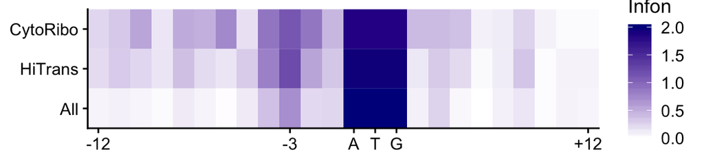

### Calculate scores of aATG, dATG, uATG against Kozak consensus

We calculate scores using Biostrings::PWMscoreStartingAt.

The best description I could find of this method is: https://support.bioconductor.org/p/61520/

It is just the sum of the matrix product of the PWM with the sequence.

Write scores to file *scores_kozak_Nc.txt*.

```
## # A tibble: 9,722 x 11
##    Gene  aATG.scorekn d1.scorekn u1.scorekn aATG.scorekw d1.scorekw
##    <chr>        <dbl>      <dbl>      <dbl>        <dbl>      <dbl>
##  1 NCU0…        0.886      0.920      0.836        0.859      0.839
##  2 NCU0…        0.797      0.866      0.743        0.718      0.760
##  3 NCU0…        0.804      0.886      0.957        0.768      0.822
##  4 NCU0…        0.809      0.889      0.694        0.767      0.818
##  5 NCU0…        0.828      0.867      0.751        0.753      0.782
##  6 NCU0…        0.975      0.930     NA            0.900      0.838
##  7 NCU0…        0.975      0.842     NA            0.926      0.708
##  8 NCU0…        0.992      0.940      0.866        0.869      0.789
##  9 NCU0…        0.827      0.833     NA            0.754      0.788
## 10 NCU0…        0.974      0.974     NA            0.862      0.871
## # ... with 9,712 more rows, and 5 more variables: u1.scorekw <dbl>,
## #   d1vsan <dbl>, u1vsan <dbl>, d1vsaw <dbl>, u1vsaw <dbl>
```

### Plot against narrow consensus (-4 to ATG)

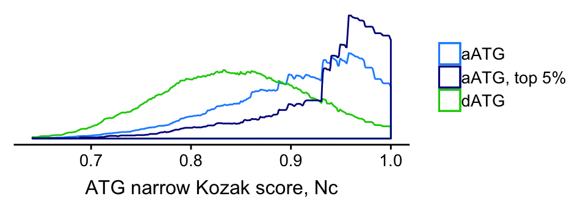

### Plot against wide consensus (-10 to ATG)

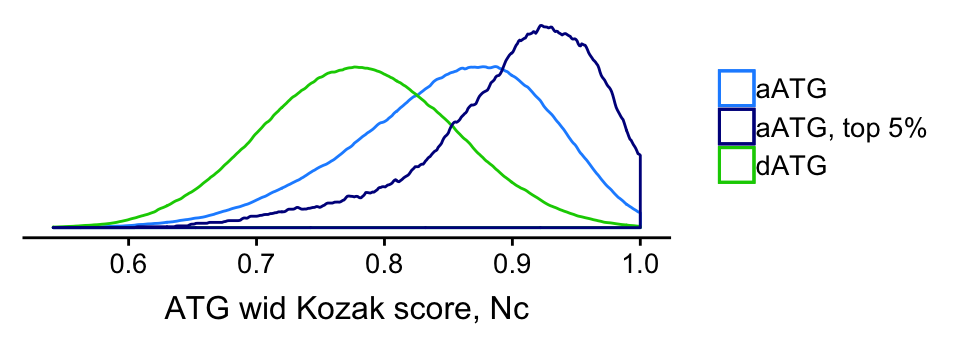

## Mutual information of different positions around ATG

### For all annotated genes

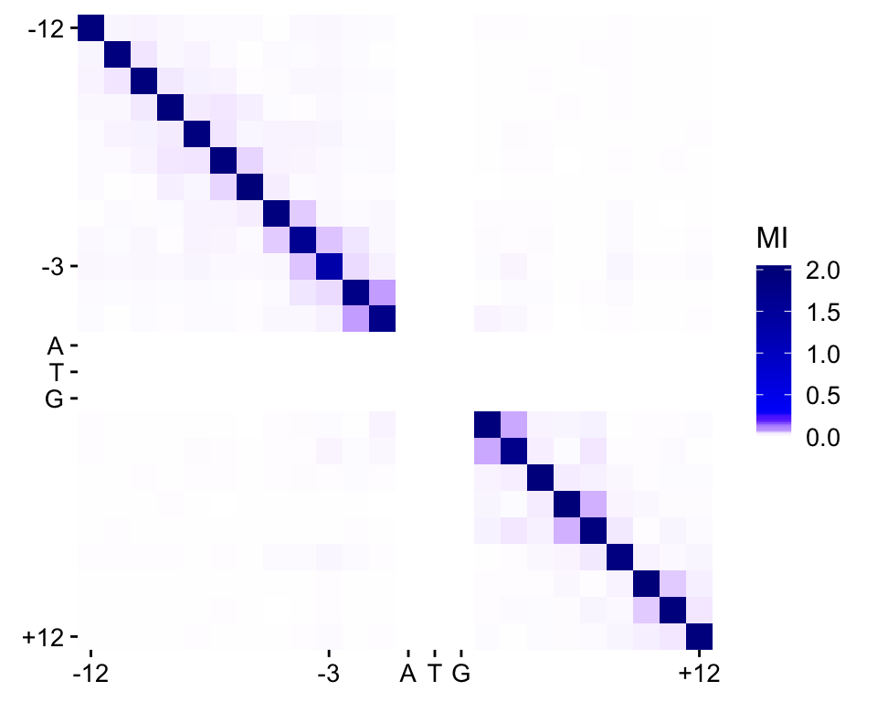

### For highly translated genes

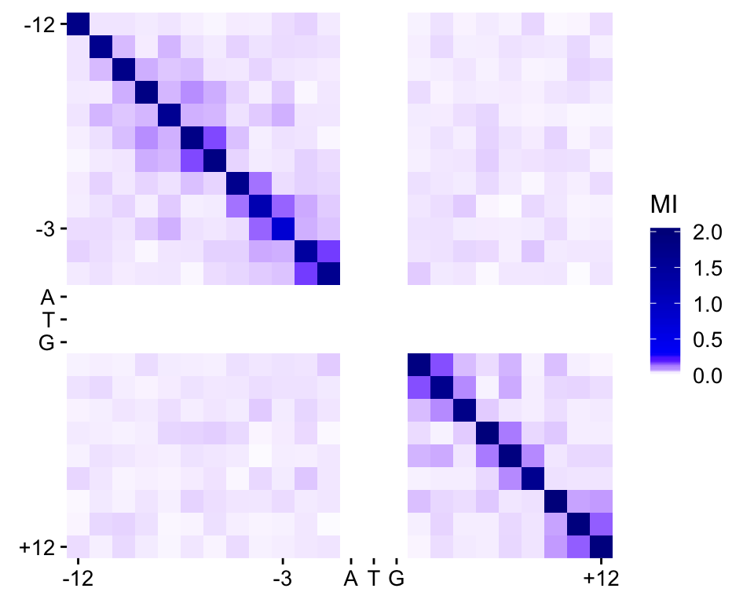

### For cytoplasmic ribosomal proteins, strong correlation between adjacent bases

This suggests the idea that an upstream CCG motif (see the logo) compensates for A’s in the classic Kozak positions closer to the ATG.

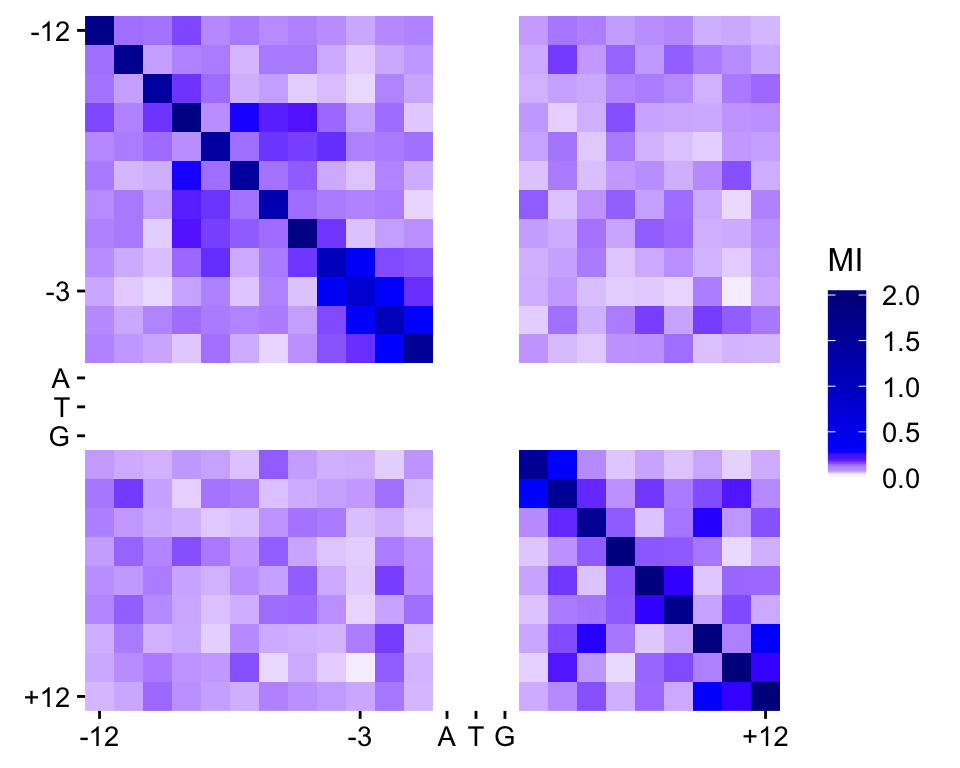

### What is the -2 correlation in cyto ribo genes?

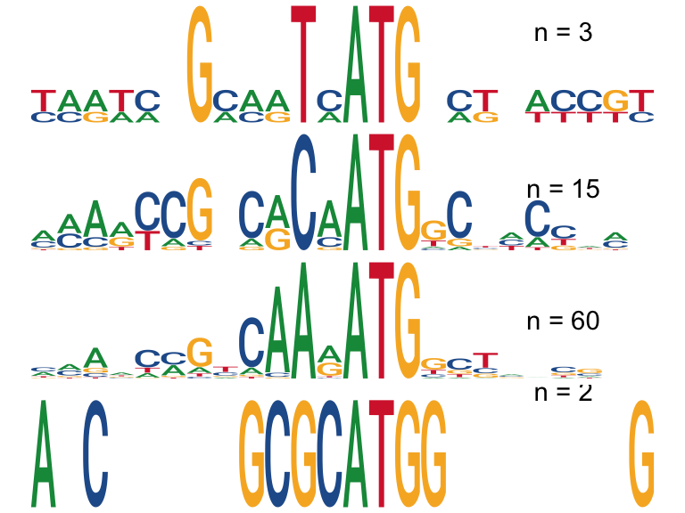

There are definitely correlations there.

### What is the -4 correlation in cyto ribo genes?

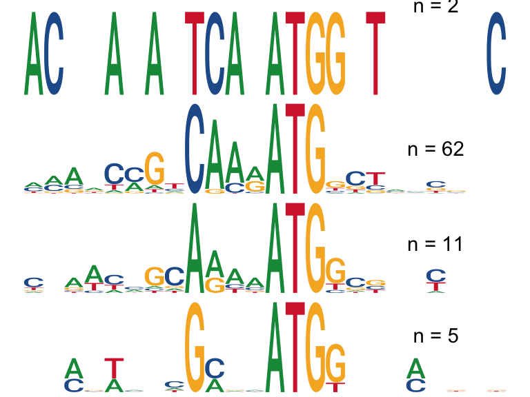

### What is the -8 correlation in cyto ribo genes?

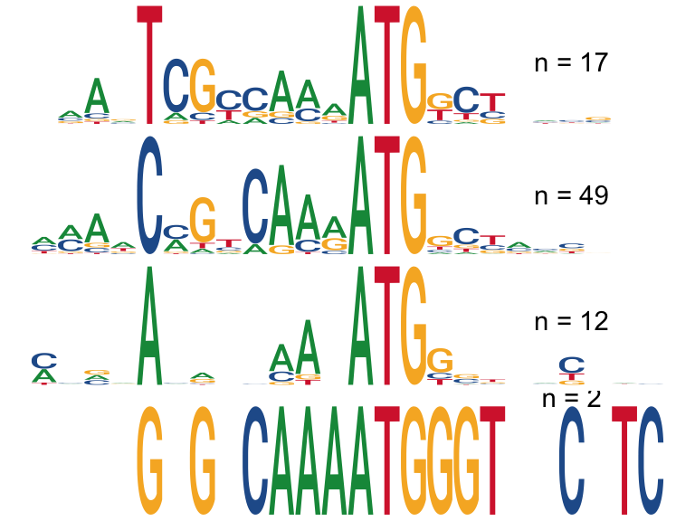

## uATGs inhibit translation of the main ORF

### uATGs are associated with slightly lower absolute translation

This is a very weak effect.

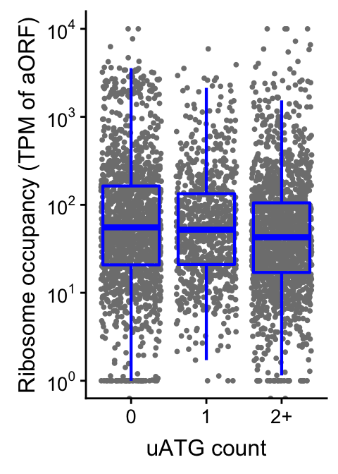

### uATGs are not associated with lower translation efficiency

But TE is from single-replicate data Yu 2015 so it may be difficult to draw conclusions.

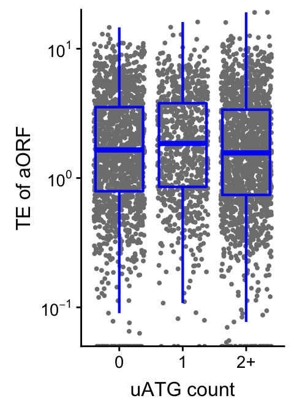

### uATGs weakly associated with lower translation efficiency might be over 20nt from TSS

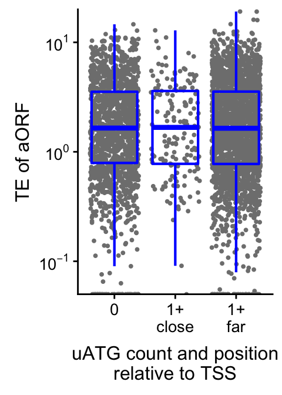

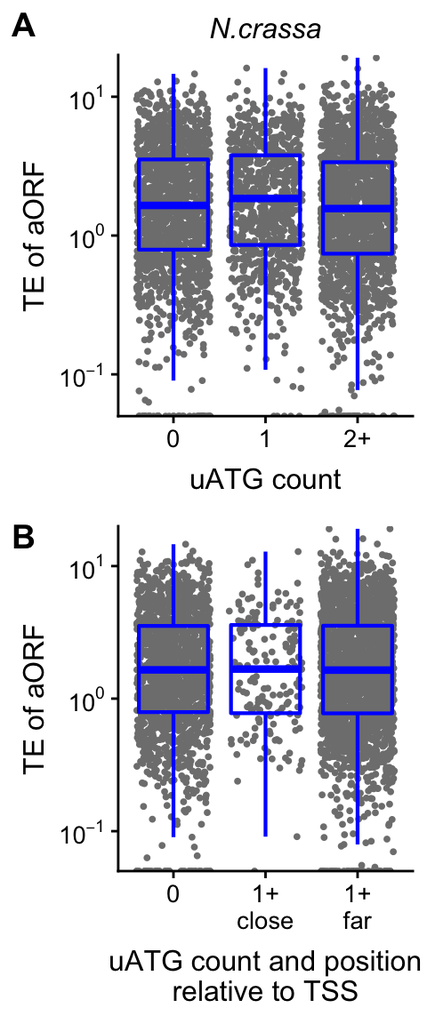

### uATG score weakly affects TE

We suspect that uATG is associated with lower TE if the uATG has

- position at least 20nt downstream from TSS
- higher score

This figure shows that, *for genes with only 1 uATG*, this correlation is weak but as expected. We would expect a stronger effect for genes with multiple uATGs of higher score. If we could model more aspects of translational efficiency we might find a stronger link.

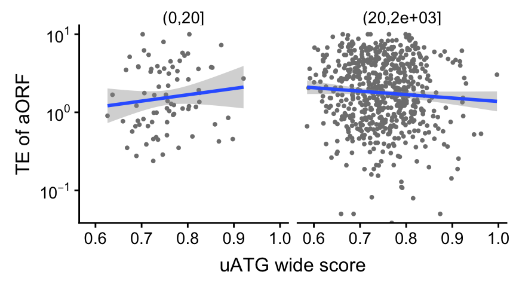

## Compare aATG and dATG context by gene

### Most dATG scores are less than aATG scores

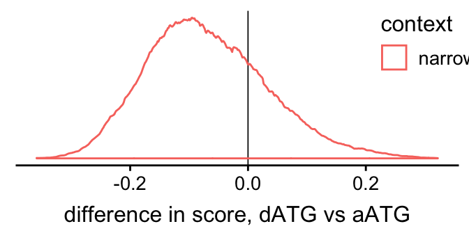

### For highly translated genes, most dATG narrow scores are much less than aATG

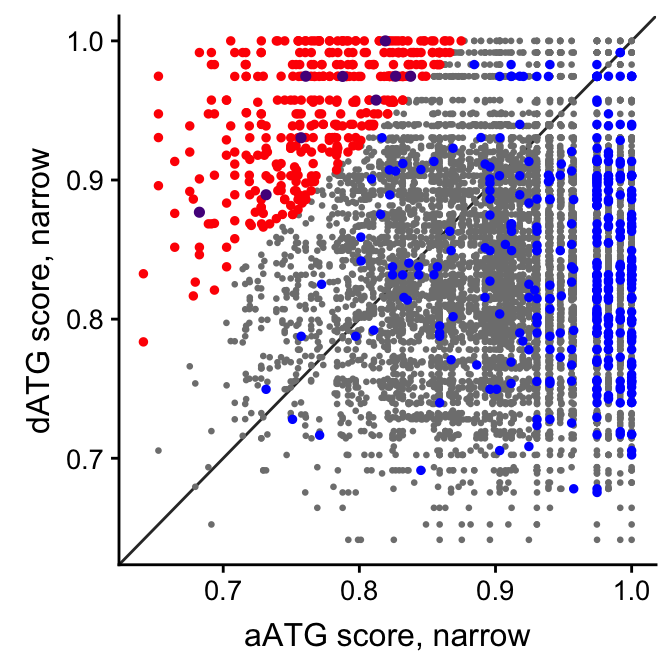

Red: high dATG vs aATG **Kozak** score. Blue: highly translated. Purple: both.

### Small negative correlation between dATG and aATG score narrow

R = -0.048

### For highly translated genes, most dATG wide scores are much less than aATG

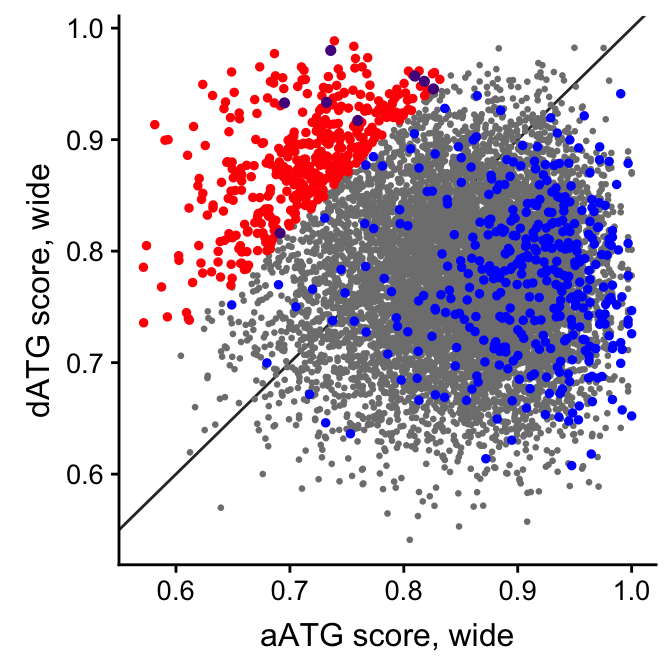

Red: high dATG vs aATG **Kozak** score. Blue: highly translated. Purple: both.

### Small negative correlation between dATG and aATG score wide

R = -0.035

## Genes with unusual dATG vs aATG narrow score

Those genes are in this list:

```
## # A tibble: 400 x 3
##    Gene     aATG.scorekn d1.scorekn
##    <chr>           <dbl>      <dbl>
##  1 NCU02127        0.652      0.975
##  2 NCU02596        0.683      0.992
##  3 NCU07312        0.691      0.992
##  4 NCU16501        0.652      0.948
##  5 NCU05040        0.706      1
##  6 NCU01333        0.691      0.983
##  7 NCU06558        0.694      0.983
##  8 NCU05555        0.708      0.992
##  9 NCU03388        0.652      0.931
## 10 NCU05710        0.714      0.992
## # ... with 390 more rows
```

- NCU05040, hypothetical conserved protein with GFA Glutathione-dependent formaldehyde-activating enzyme domain. JEC21 homolog is CNC03895
- NCU02127 methylcrotonyl carboxylase-2, mcc-2
- NCU05555, hypothetical protein
- NCU07312, hypothetical protein sgr-24
- NCU12086, hypothetical protein
- NCU02616, WD-repeat containing protein slp1/cdc20
- NCU01333, Delta(24(24(1)))-sterol reductase erg-4, ER localized in Scer
- NCU03699, zinc finger transcription factor-13, znf-13
- NCU05306, hypothetical protein, homolog of Scer DAN4, CNJ01800 and SPBC725.03 (pyridoxamine 5’-phosphate oxidase, cell wall mannoprotein)
- NCU06558 D-amino-acid oxidase oxD, many Crypto homologs (CNAG_02532/CNAG_05802/CNAG_03562/) Sp dao1.

Some of these are well translated:

```
## # A tibble: 9 x 5
##   Gene     aATG.scorekn d1.scorekn d1.frame d1.posATG
##   <chr>           <dbl>      <dbl>    <dbl>     <dbl>
## 1 NCU04510        0.761      0.975        0        81
## 2 NCU01981        0.683      0.877        1       112
## 3 NCU00405        0.788      0.974        0       207
## 4 NCU01418        0.819      1            0       243
## 5 NCU01221        0.757      0.930        0        87
## 6 NCU08502        0.731      0.889        0        93
## 7 NCU00867        0.827      0.975        0       111
## 8 NCU12024        0.812      0.957        1        58
## 9 NCU09331        0.838      0.975        0       114
```

- NCU00405 glycyl-tRNA synthetase 1
- NCU01418 clock-controlled gene-6, ccg-6, SPI1 homolog
- NCU09560 superoxide dismutase-3 sod-3
- NCU01221 RPL16/crp-46, check annotation, suspect N-terminal isn’t actually there as not homologous to RPL16 or structured.
- NCU08502 RPS6/crp-14
- NCU04510 aldose reductase gcy-3, Scer homologs YPR1/GCY1 (both cyto/nuc), GRE3, YJR096W
- NCU09331 HMF1, homolog of Scer HMF1 (cyto) / MMF1 (mito) *which have the same aATG/aATG architecture in S. pombe*
- NCU00629 6-phosphofructokinase emp-3
- NCU01981 translation factor SUI1/eIF1
- NCU07408 po / RPP0

### dATG in frame with ATG

Files with high difference in narrow score, filtered for reasonable amounts of RNA translation, in frame. Saved to *dvsaATG_highdiffn_inframe_Nc.txt*.

```
## # A tibble: 118 x 3
##    Gene     aATG.scorekn d1.scorekn
##    <chr>           <dbl>      <dbl>
##  1 NCU02127        0.652      0.975
##  2 NCU02596        0.683      0.992
##  3 NCU05040        0.706      1
##  4 NCU01333        0.691      0.983
##  5 NCU06558        0.694      0.983
##  6 NCU01121        0.717      0.992
##  7 NCU07509        0.728      0.992
##  8 NCU10044        0.675      0.939
##  9 NCU03605        0.740      1
## 10 NCU03793        0.717      0.974
## # ... with 108 more rows
```

### dATG out of frame with ATG

Files with high difference in narrow score, filtered for reasonable amounts of RNA translation, out of frame. Saved to *dvsaATG_highdiffn_outframe_Nc.txt*.

```
## # A tibble: 46 x 3
##    Gene     aATG.scorekn d1.scorekn
##    <chr>           <dbl>      <dbl>
##  1 NCU00372        0.728      1
##  2 NCU03221        0.728      0.992
##  3 NCU03054        0.664      0.913
##  4 NCU16316        0.717      0.948
##  5 NCU07528        0.755      0.974
##  6 NCU02547        0.675      0.892
##  7 NCU01283        0.791      1
##  8 NCU04195        0.750      0.957
##  9 NCU03653        0.752      0.957
## 10 NCU01981        0.683      0.877
## # ... with 36 more rows
```

### dATG in frame with ATG, wide

Files with high difference in wide score, filtered for top 40% by RNA abundance, in frame. Saved to *dvsaATG_highdiffw_inframe_Nc.txt*.

```
## # A tibble: 123 x 3
##    Gene     aATG.scorekw d1.scorekw
##    <chr>           <dbl>      <dbl>
##  1 NCU01121        0.649      0.961
##  2 NCU04323        0.632      0.940
##  3 NCU01333        0.593      0.900
##  4 NCU07509        0.651      0.942
##  5 NCU00847        0.686      0.977
##  6 NCU05306        0.643      0.934
##  7 NCU02127        0.642      0.928
##  8 NCU02511        0.687      0.957
##  9 NCU02596        0.626      0.895
## 10 NCU07657        0.686      0.951
## # ... with 113 more rows
```

### dATG out of frame with ATG, wide

Files with high difference in wide score, filtered for top 40% by RNA abundance, out of frame. Saved to *dvsaATG_highdiffw_outframe_Nc.txt*.

```
## # A tibble: 49 x 3
##    Gene     aATG.scorekw d1.scorekw
##    <chr>           <dbl>      <dbl>
##  1 NCU01897        0.633      0.841
##  2 NCU08779        0.704      0.907
##  3 NCU02547        0.652      0.854
##  4 NCU07384        0.683      0.878
##  5 NCU16446        0.748      0.942
##  6 NCU03221        0.698      0.885
##  7 NCU02635        0.745      0.930
##  8 NCU04037        0.688      0.869
##  9 NCU06259        0.735      0.914
## 10 NCU04637        0.728      0.902
## # ... with 39 more rows
```

## Compare score difference to localization predictions

### Load predictions from mitofates

In input file *NC12_mitofates.txt*.

### Nc Genes with high dATG vs aATG score *are* enriched in mitochondrial presequences

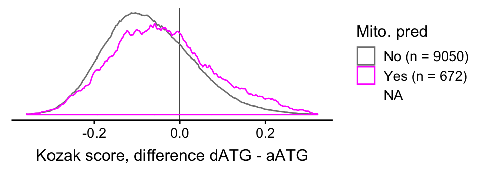

### Spectacular correlations between d1 score, d1 frame, and localization

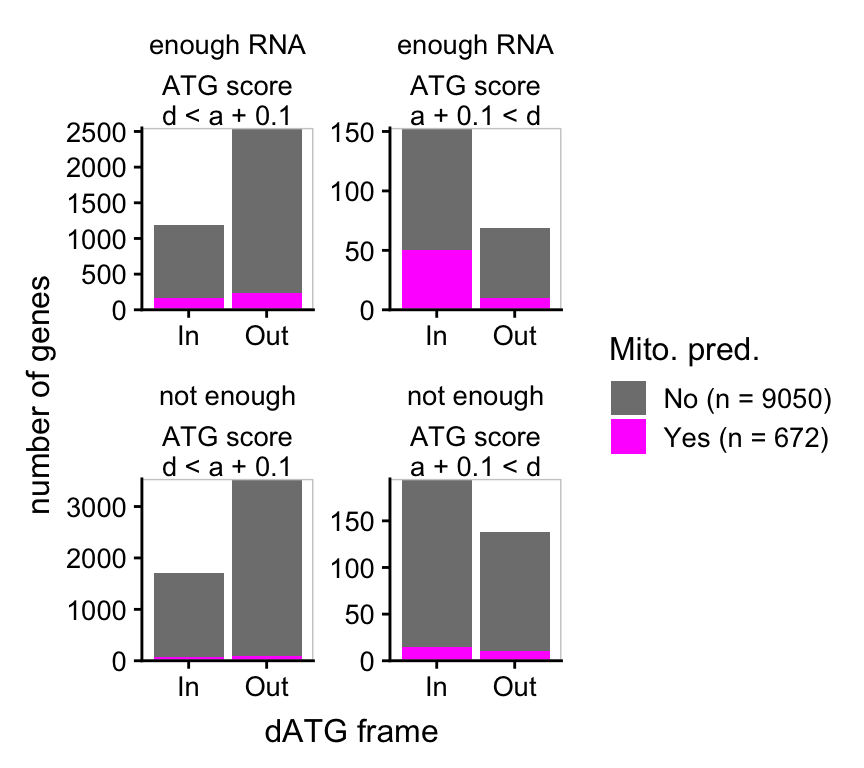

### Count dATG vs ATG score, d1 frame, mito pre, enough RNA

```
## # A tibble: 16 x 5
## # Groups:   enoughR, d1vsaw0p1, d1.framefac [?]
##    enoughR d1vsaw0p1 d1.framefac Pred_preseq     n
##    <fct>   <fct>     <fct>       <fct>       <int>
##  1 Yes     d1lo      In          No           1028
##  2 Yes     d1lo      In          Yes           164
##  3 Yes     d1lo      Out         No           2308
##  4 Yes     d1lo      Out         Yes           242
##  5 Yes     d1hi      In          No            103
##  6 Yes     d1hi      In          Yes            50
##  7 Yes     d1hi      Out         No             59
##  8 Yes     d1hi      Out         Yes            10
##  9 No      d1lo      In          No           1627
## 10 No      d1lo      In          Yes            72
## 11 No      d1lo      Out         No           3437
## 12 No      d1lo      Out         Yes           101
## 13 No      d1hi      In          No            180
## 14 No      d1hi      In          Yes            15
## 15 No      d1hi      Out         No            128
## 16 No      d1hi      Out         Yes            10
```

### Nc mito-localized genes also do not have a distinctive aATG context

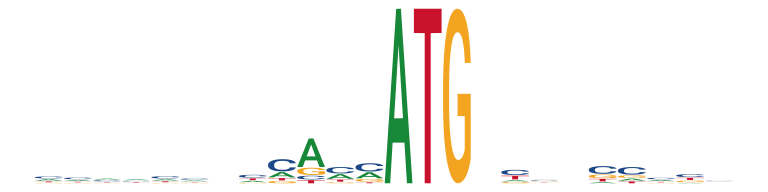

## Genes with unusual dATG vs aATG narrow score AND predicted mito loc

Those genes are in this list:

```
## # A tibble: 64 x 12
##    Gene  aATG.scorekn d1.scorekn d1.frame d1.posATG  WT1A  WT1B  WT2A  WT2B
##    <chr>        <dbl>      <dbl>    <dbl>     <dbl> <dbl> <dbl> <dbl> <dbl>
##  1 NCU0…        0.652      0.975        0        45   2.3   3.3   5.4   4.5
##  2 NCU0…        0.706      1            0       141   2.8   1.9   0.6   1.4
##  3 NCU0…        0.716      0.983        0       177   6.6   6.9   8.2   6.6
##  4 NCU0…        0.708      0.974        0       183   5.8   5.3   4.3   5.1
##  5 NCU1…        0.675      0.939        0        78  15.4  14.4  13.7  17.9
##  6 NCU0…        0.740      1            0       282  18.7  17.4  25.8  20.1
##  7 NCU0…        0.689      0.948        0        21   3.2   3.6   1.8   0.7
##  8 NCU0…        0.717      0.974        0       129  21.7  20.4   8.6  10.7
##  9 NCU0…        0.664      0.913        2       107  22.8  21.2  24.6  28.8
## 10 NCU0…        0.755      1            0        75 126.  139.   77.1  73.3
## 11 NCU0…        0.755      1            0       162  50.2  44.6  48.4  48
## 12 NCU0…        0.754      0.983        0       177  24.4  24.8  23    25
```

[output cut: 16 more lines]

Most have in-frame ATG

- NCU05040 again
- NCU02127 again
- NCU08568 adenine-19, ad-19, Scer homolog YSA1 is dual-localized.
- NCU03605 amidohydrolase
- NCU10044 hypothetical protein apn-1, AP endonuclease, Sc APN1 dula-localized mito/nuc.
- NCU06615 hypothetical protein, CNAG_06355 homolog, bacterial homologs (YccU in E coli), CoA binding domain, likely mitochondrial.
- NCU01307 hypothetical protein
- NCU03859 MYG1 protein, homologous to mammalian MYG1/Gamm1 which is dual mito/nuc localized, and CNAG_06946 which has same structure.
- NCU01784 pseudouridylate synthase 3 psu-3, tRNA-PUS, DEG1 homolog
- NCU07528 tRNA-pseudouridine synthase-1, tpus-1 dual-loc conserved
- NCU03054 hypothetical protein, paralog of NCU08606, ortholog of ACK1 (mito), SHC1 (?), DSF2 (bud tip)
- NCU03793 hypothetical protein, CNAG_07308/CNA00310 homolog, aflatoxin biogenesis/HypA related.
- NCU08195 ArgRS
- NCU00405 GlyRS
- NCU00742 glycerol-3-phosphate dehydrogenase glp-1, Scer homologs GPD1/GPD2 dual-localized.
- NCU11195 D-isomer specific 2-hydroxyacid dehydrogenase
- NCU00847 hypothetical protein, putative methyltransferase/methoxylase/GA4 desaturase family protein
- NCU03696 nitroreductase, Scer HBN1 & FRM2 homolog, CNAG_02692 (mito) homolog.
- NCU03339 Glutathione reductase gtr-1, GLR1 homolog Cytosolic and mitochondrial glutathione reductase.

### Some more decently-translated ones

```
## # A tibble: 16 x 12
##    Gene  aATG.scorekn d1.scorekn d1.frame d1.posATG  WT1A  WT1B  WT2A  WT2B
##    <chr>        <dbl>      <dbl>    <dbl>     <dbl> <dbl> <dbl> <dbl> <dbl>
##  1 NCU0…        0.755      1            0        75 126.  139.   77.1  73.3
##  2 NCU0…        0.719      0.939        0        33  95.7  94.5  86.1  80
##  3 NCU0…        0.761      0.975        0        81 851.  843.  212   163.
##  4 NCU0…        0.773      0.983        0       282 257.  254.  218.  206.
##  5 NCU0…        0.784      0.992        0       105 195.  211.  266.  231.
##  6 NCU0…        0.752      0.957        2       101  52.7  52.1  85.8  90.4
##  7 NCU0…        0.788      0.974        0       207 431.  419.  400.  362.
##  8 NCU0…        0.818      1            0       375  44.4  42.5  65.2  59.6
##  9 NCU0…        0.740      0.909        0         6  42.6  49    57.7  56.2
## 10 NCU0…        0.824      0.992        2        89  87.7  92.4  63.9  63.5
## 11 NCU0…        0.774      0.940        0       129 321.  330.  221.  211.
## 12 NCU0…        0.784      0.939        0       225 114.  120.  120.  104
## 13 NCU0…        0.807      0.957        1       142  61.7  55.2  68.9  50.1
## 14 NCU0…        0.811      0.948        0       111  72.3  72    53.3  48.1
## 15 NCU0…        0.857      0.983        0       135 117.  120.   57.1  51.1
## 16 NCU0…        0.755      0.879        0         3  78    78.8  70.5  78.1
## # ... with 3 more variables: HS1A <dbl>, HS1B <dbl>, RPF <dbl>
```

- NCU03749 pyruvate-1 pru-1, GLO2/GLO4 homolog
- NCU06877 CRAL/TRIO domain-containing protein, CSR1 homolog dual-localized.
- NCU06108 UPF0135, NIF3 homolog
- NCU05805 Serine hydroxymethyltransferase cbs-2, SHM1 (mito) and SHM2 (cyto) homolog.
- NCU01501 mitochondrial peptidyl-tRNA hydrolase Pth2
- NCU03177 sco1, Scer homologs are mitochondrial, only 2 codons between ATGs.
- NCU01965 ValRS
- NCU09536 conserved hypothetical protein
- NCU02701 dipeptidyl peptidase dpp-2, YOL057W homolog
- NCU00936 succinate-3 suc-3; Cneo has homologs CNAG_01027 (mito) and CNAG_04467 (not); Scer has a single homolog UGA2, mostly cytoplasmic

Back to table of contents